# Math Camp - Probability and Distributions Code Session

# Questions from Morning Session

[figure not shown]

# Types of Data

**What are the four types of data?**

# Types of Data

**What are the four types of data?**

- Categorical
- Ordinal
- Interval
- Ratio

# Types of data in R

- We talk about data “class” in R
- Class = category
- There are three main classes of data in R
1. Numeric/Integer
2. Factor
3. Character

# Numeric/Integer Data

- Corresponds to Interval and Ratio data types
- R does not differentiate between Interval and Ratio
- R differentiates between *integer* data and *numeric* data
- Integer data are whole numbers
- Numeric data includes decimals

# Numeric/Integer Data

Let’s make a vector object $x$ that is numbers from 0-10.

An **object** is anything you’ve saved in R. It will appear in your working environment.

A **vector** is a sequence of data elements of the same type.

**Elements** are the components of a vector.

# Numeric/Integer Data

Okay, now that we know what a vector is, let’s make one.

```r
x <- 0:10 # making x
x # here is what I made.
```

```
##  [1]  0  1  2  3  4  5  6  7  8  9 10
```

These numbers are the elements/components of vector $x$. $x$ is an object.

We use the $class$ function to find the data class of the object.

```r
class(x)
```

```
## [1] "integer"
```

Because $x$ is an integer variable, we can get its mean.

```r
mean(x)
```

```
## [1] 5
```

# Numeric/Integer Data

Now let’s make $x1$ numbers from -5 to 5.

```r
x1 <- -5:5
x1
```

```
##  [1] -5 -4 -3 -2 -1  0  1  2  3  4  5
```

```r
class(x1)
```

```
## [1] "integer"
```

```r
mean(x1)
```

```
## [1] 0
```

R does not care that $x$ has a true 0 and $x1$ goes negative (interval vs ratio). Both are integers.

# Numeric/Integer Data

Now let’s make $y$ from -1 to 5, by 0.5 intervals.

```r
(y <- seq(-1,5,0.5)) # making  and showing y
```

```
##  [1] -1.0 -0.5  0.0  0.5  1.0  1.5  2.0  2.5  3.0  3.5  4.0  4.5  5.0
```

```r
class(y)
```

```
## [1] "numeric"
```

Because $y$ is not whole numbers, R calls it “numeric” but not “integer”.

# Numeric/Integer Data

Let’s make another object called $x2$. $x2$ will be $x$ but with one additional element, 10.5, added to the end of the vector.

```r
x2 <- c(x,10.5) # making x2
x2 # notice the decimal points
```

```
##  [1]  0.0  1.0  2.0  3.0  4.0  5.0  6.0  7.0  8.0  9.0 10.0 10.5
```

```r
x # notice the lack of decimal points
```

```
##  [1]  0  1  2  3  4  5  6  7  8  9 10
```

The decimal points indicate that $x2$ is numeric. We can also see that with the class function.

```r
class(x)
```

```
## [1] "integer"
```

```r
class(x2)
```

```
## [1] "numeric"
```

R will automatically reclassify integer data as numeric when we add a non-integer.

# Numeric/Integer Data

Questions?

# Factor Data

Factor data corresponds to *categorical* and *ordinal* data.

Let’s make some categorical data.

```r
(cats <- factor(c("small", "medium", "large", "ruh-roh")))
```

```
## [1] small   medium  large   ruh-roh
## Levels: large medium ruh-roh small
```

```r
class(cats)
```

```
## [1] "factor"
```

# Factor Data

“Numbers” can also be factor data, but R will not treat them like numeric/integer data.

Let’s make a *factor* that is the numbers 7-10.

```r
(nums <- factor(c(7:10)))
```

```
## [1] 7  8  9  10
## Levels: 7 8 9 10
```

**Show me the class of “nums”**

```r
# work here
```

# Factor Data

R considers these categorical data and so cannot calculate a mean, even though this looks like numbers to us!

```r
mean(nums)
```

```
## [1] NA
```

# Factor Data

Now let’s make that categorical data into ordinal data by telling R the order.

```r
cats # remember the categories.
```

```
## [1] small   medium  large   ruh-roh
## Levels: large medium ruh-roh small
```

```r
(cats2 <- ordered(cats, levels = c("small", "medium", "large", "ruh-roh")))
```

```
## [1] small   medium  large   ruh-roh
## Levels: small < medium < large < ruh-roh
```

Notice the < signs indicate ordering in $cats2$.

# Factor Data

We can also make the $nums$ object into an ordered factor, but be careful to always set the ordering or you will get some surprises. Remember, R does *not* consider these as numbers.

```r
moreNums <- c(nums, "11") # add an 11 to the end of nums.
(nums1 <- ordered(moreNums))
```

```
## [1] 1  2  3  4  11
## Levels: 1 < 11 < 2 < 3 < 4
```

```r
(nums1 <- ordered(moreNums, levels=c(7,8,9,10,11)))
```

```
## [1] <NA> <NA> <NA> <NA> 11
## Levels: 7 < 8 < 9 < 10 < 11
```

Even ordered, $nums1$ is still not numeric so R will still not calculate a mean.

```r
class(nums1)
```

```
## [1] "ordered" "factor"
```

```r
mean(nums1)
```

```
## [1] NA
```

# Factor Data

Easy factor mistakes.

```r
cats
```

```
## [1] small   medium  large   ruh-roh
## Levels: large medium ruh-roh small
```

```r
(mistake <- c(cats, "huge"))
```

```
## [1] "4"    "2"    "1"    "3"    "huge"
```

As a factor, R thinks it knows the only possible categories of $cats$ and will not accept additions.

```r
levels(cats) # the only values it can take
```

```
## [1] "large"   "medium"  "ruh-roh" "small"
```

# Factor Data

This also applies to factors that look like numbers.

```r
nums
```

```
## [1] 7  8  9  10
## Levels: 7 8 9 10
```

```r
(wrong <- c(nums, 11))
```

```
## [1]  1  2  3  4 11
```

R will rename everything as “1st factor”, “2nd factor”, “3rd factor”, etc, and then add the new factor level (“11”) to that.

# Factor Data

Factors can be annoying.

The third type of data, “characters”, does not add the constraints of factor variables and is easier to manipulate.

# Character Data

First thing: character data is not really data!

It is just letters/numbers, a “character string”.

```r
(string <- c("hello", "how are you", "I am fine"))
```

```
## [1] "hello"       "how are you" "I am fine"
```

```r
class(string)
```

```
## [1] "character"
```

# Character Data

We can add things to this!

**Add “how’s your family” to the string.**

```r
# work here
```

# Character Data

Character data does not have levels. The way to see all the response options is to make a table.

```r
levels(string)
```

```r
table(string)
```

```
## string
##       hello how are you   I am fine
##           1           1           1
```

# Character Data

Numbers can be character variables. As with factors, R will not consider these to be numbers with numeric properties, just symbols.

```r
(string1 <- c("1", "2", "3", "4"))
```

```
## [1] "1" "2" "3" "4"
```

```r
class(string1)
```

```
## [1] "character"
```

```r
mean(string1) # these are not numbers
```

```
## [1] NA
```

# Character Data

We can still add things to it without a problem, both numbers and words. It reads all of these things as characters without numeric properties.

```r
(yep <- c(string1, 10, "huge"))
```

```
## [1] "1"    "2"    "3"    "4"    "10"   "huge"
```

# Changing Data Class

You can change data class easily. But be careful when changing! You *almost always* change something into a character before changing into a factor/numeric.

```r
nums; class(nums)
```

```
## [1] 7  8  9  10
## Levels: 7 8 9 10
```

```
## [1] "factor"
```

```r
as.numeric(nums) # uhoh!
```

```
## [1] 1 2 3 4
```

```r
as.numeric(as.character(nums)) # there we go
```

```
## [1]  7  8  9 10
```

# Let’s practice!

**Make a numeric vector of all even numbers from 0 to 100, including 0 and 100**

```r
# work here

# try using the seq function.
#?seq
```

# Let’s practice!

**Make an ordered factor from “mild” to “diablo” with a few other categories in between.**

```r
 # work here
```

# Types of data in R

Questions?

# Break

When we return, we will cover random variables and (mostly) distributions.

# Random Variable

**What is a random variable?**

# Random Variable

**What is a random variable?**

“Numerical measure of the outcome of a probability experiment whose value is determined by chance”.

This is **not** an algebraic variable with a single value. $18 = 2 + 2x; x = 8$.

A “random variable” is a function that arises from a random process/random event. It describes the possible outcomes of the random event and their probabilities.

We can say that a random variable quantifies outcomes of a random event.

# Random Variable

**What is a random event?**

# Random Variable

**What is a random event?**

An event with multiple potential outcomes, like a dice roll. Rolling dice is a random process/random event.

A random variable quantifies the outcomes of a random event. It tells us what could happen when we roll dice.

Rather than talking about a random variable as a single value, $x=8$, we talk about the probability that the random variable takes certain values, $P(X=6)$, or a range of values, $P(X<4)$.

We need to quantify outcomes so that we can do mathematics on the outcomes.

An event with just one potential outcome is *deterministic* and not a random event. Like water becoming gas at its boiling point. It always happens and there is no other possible outcome. Water never freezes at its boiling point. Water never becomes peanut butter at its boiling point.

# Random Variable

Let’s code a dice roll.

```r
# make the dice
dice <- function(rolls)
{
  x <- sample(x = c(1:6), size = rolls, replace=TRUE)
  return(x)
}

# now roll the dice
dice(1)
```

```
## [1] 2
```

```r
dice(1)
```

```
## [1] 6
```

```r
dice(1)
```

```
## [1] 4
```

# Random Variable

Now let’s roll it 10,000 times.

```r
diceRolls <- dice(10000) # rolling the dice
mean(diceRolls) # average roll
```

```
## [1] 3.5205
```

```r
length(diceRolls) # number of rolls
```

```
## [1] 10000
```

```r
head(diceRolls) # show the first 6 rolls
```

```
## [1] 5 5 5 2 3 1
```

This is a random event. The random variable assigns values to the outcomes of the random event.

# Random Variable

We rolled the dice 10,000 times and called it $diceRolls$.

We might want to know the probability of getting exactly a 4 or the probability of getting a 4 or higher on these dice rolls.

# Random Variable

Now let’s code a rigged die that rolls a 1 1/3 of the time and a 6 only 1/12 of the time.

```r
dice_bad <- function(rolls)
{
  x <- sample(x = c(1:6), size = rolls, replace=T, prob=c(1/3,1/6,1/6,1/6,1/6,1/12))
  return(x)
}

# now roll the dice
dice_bad(1)
```

```
## [1] 5
```

```r
dice_bad(1)
```

```
## [1] 1
```

```r
dice_bad(1)
```

```
## [1] 6
```

# Random Variable

Now let’s roll this rigged die 10,000 times.

```r
badRolls <- dice_bad(10000)
tail(badRolls) # show the bottom 6
```

```
## [1] 2 1 5 5 5 1
```

**Get the mean of all the rigged dice rolls.**

```r
# work here
```

# Random Variable

Rolls of both of those dice rolls are *random events*. A random event does not require all potential outcomes to occur with equal probability, it just requires that we cannot perfectly predict the outcome.

When we can perfectly predict the outcome of an event, we could say this is a deterministic event.

In social science, we rarely have deterministic events! That is why we use statistics and probability.

We tend to care about random variables that are influenced by some other variable, such as intergroup contact influencing intergroup prejudice. We can define these as random variables (high prejudice, low prejudice) and analyze how one influences the other.

# Random Variable

Questions?

# Distributions

**What is a distribution?**

# Distributions

**What is a distribution?**

*A probability distribution is a table or an equation that links each outcome of a statistical experiment with its probability of occurrence.*

A description of the number of times each outcome occurs in a number of trials/observations.

Examples:

1. Amount of time each person in the world spends watching the World Cup.
2. Height of people in the city of Champaign.

# Distributions

We have already made distributions for our dice rolls!

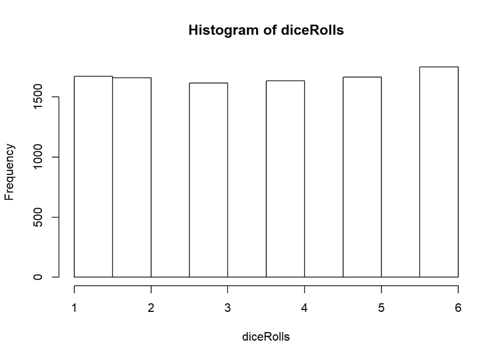

```r
hist(diceRolls)
```

This is a *discrete uniform distribution*. Discrete because there are a set number of outcomes. Uniform because each outcome occurs with equal probability.

It describes the frequency with which we see each outcome.

In expectation, 10,000 rolls / 6 sides = 1,666.667 instances of each outcome.

# Distributions

Social and physical processes in the world are described by a variety of distributions.

Distributions can be *discrete* or *continuous*.

Let’s review some of the most common and see how to create them in R, starting with discrete distributions.

Remember that a discrete distribution is a distribution with a set number of outcomes.

# Binomial Distribution

**What is a binomial distribution?**

# Binomial Distribution

**What is a binomial distribution?**

The distribution for a random event with outcomes that are just 1s and 0s. Some number of coins flipped some number of times.

**Using my code above for dice rolls, try to write a function for a coin flip!**

```r
# work here
```

**Randomly select someone to show us their function**

```r
people <- c("Matt", "Dylan", "CJ", "Seung-Uk"
           , "Aleena", "Moon Young", "Jiyoung"
           , "Jair", "Stephen"
           )
sample(people,1)
```

```
## [1] "Matt"
```

# Binomial Distribution

Let’s flip ten coins and see how many come up heads!

```r
# Using class's function
```

# Binomial Distribution

Now let’s flip 10 coins 10,000 times to get a binomial distribution.

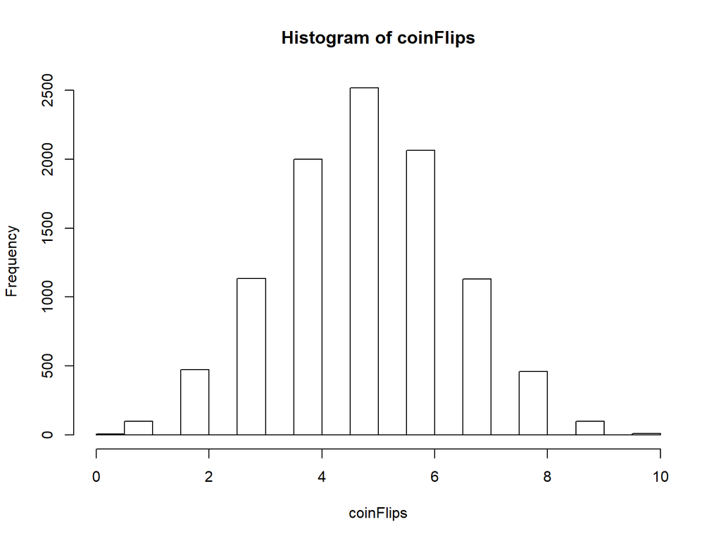

```r
# with the function we've likely written
#coinFlips <- mosaic::do(10000)*coins(10)

# with rbinom
coinFlips <- rbinom(n=10000, size=10, prob=0.5)
hist(coinFlips)
```

This distribution shows us the number of times, out of 10,000, we observe a given number of heads. Theoretically, we could observe as low as 0 heads and as high as 10 heads.

# Binomial Distribution

Because the binomial distribution is so common, R has built-in functions for binomial distributions. It does what we just coded above. We’ll use that from now on.

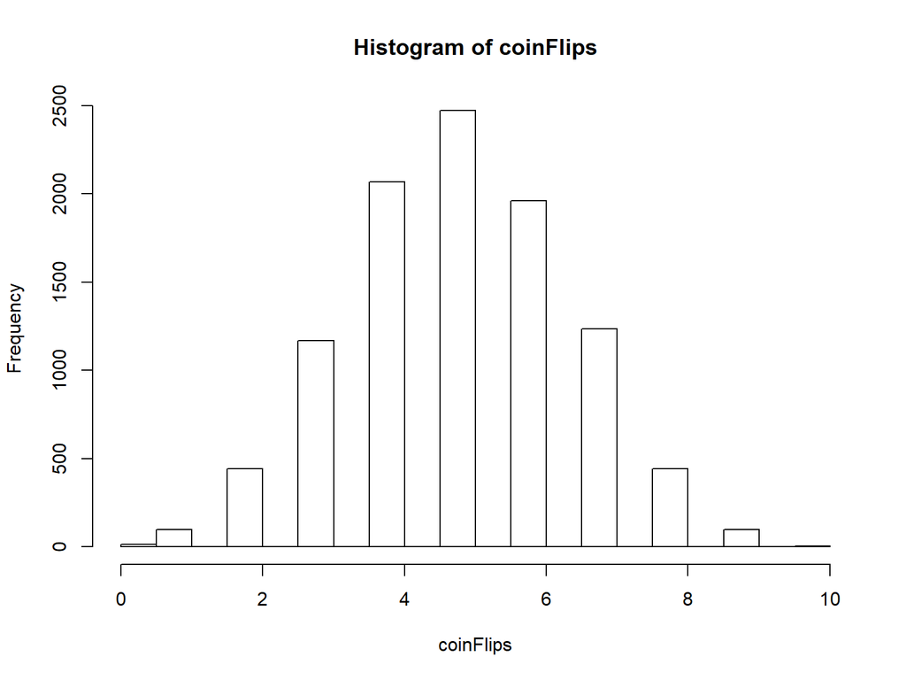

```r
coinFlips <- rbinom(n=10000, size=10, prob=0.5)
hist(coinFlips)
```

When flipping 10 coins, often get 2 or 8 heads.

# Binomial Distribution

**What if we flipped 100 coins? Would we often get 20 or 80 heads?**

# Binomial Distribution

Let’s flip 100 coins.

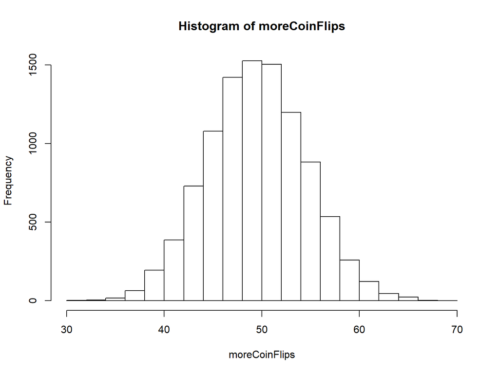

```r
moreCoinFlips <- rbinom(n=10000, size=100, prob=0.5); theBinom <- moreCoinFlips
hist(moreCoinFlips)
```

```r
range(moreCoinFlips)
```

```
## [1] 31 70
```

# Binomial Distribution

What if we flipped 1,000 coins? Would we ever get 200 or 800 heads?

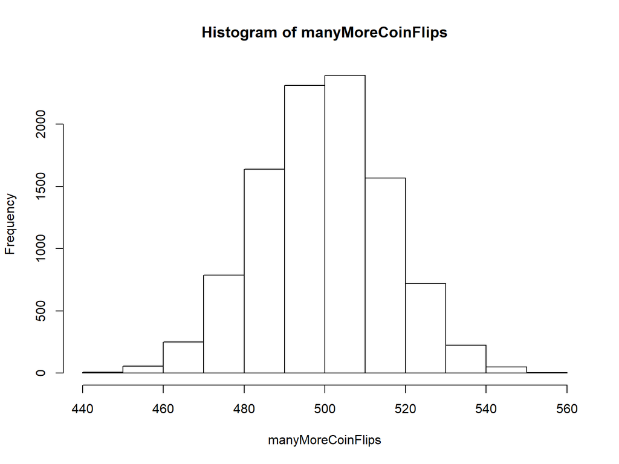

```r
manyMoreCoinFlips <- rbinom(n=10000, size=1000, prob=0.5)
hist(manyMoreCoinFlips)
```

```r
range(manyMoreCoinFlips)
```

```
## [1] 440 557
```

# Binomial Distribution

Earlier today you also looked at density functions.

Remember: the probability mass function, pmf $f(x)$, is the function that tells the probability that a given value will occur $P(X = x)$.

```r
# probability of getting 5 successes out of 10 trials -- probability mass function
dbinom(x = 5, size = 10, prob=0.5)
```

```
## [1] 0.2460938
```

Remember: the cumulative distribution function, CDF $F(x)$, is the function that tells us the cumulative probability that a given value or any value smaller than it will occur

```r
# probability of getting 5 or fewer successes out of 10 trials -- cumulative probability distribution function
pbinom(q = 5, size=10, prob=0.5)
```

```
## [1] 0.6230469
```